# APEX active layer analysis

Manies

2022-03-23

Needed libraries:

```r
library(lubridate)
library(ggplot2)
library(dplyr)   #left_join
```

## Importation of data files

The data included in this analysis are from various sources. All data are originally from Excel files where a tab was saved in csv format.

```r
guelph <- read.csv("raw_data/Seasonal Thaw Depth Data Dielman.csv",header=TRUE)
usgs1 <- read.csv("raw_data/FINAL End of Season usgs.csv",header=TRUE)
crell <- read.csv("raw_data/douglas APEX ERT lines thaw depths October 2017.csv", header=TRUE)
geo.1819.data <- read.csv("raw_data/APEX_2018_2019_Adjusted_ThawDepth_Data.csv", header=TRUE)
geo.now.data <- read.csv("raw_data/APEX_2020_present_ThawDepth_Data.csv", header=TRUE)
apex.data <- read.csv("raw_data/APEX_non_geophysical_thaw_depths.csv", header=TRUE)
region <- read.csv("APEX_GPS_locations.csv", header=TRUE)
```

Add a column to each dataset so we know where the data is from.

```r
usgs1 <- cbind(usgs1, source="USGS")
guelph <- cbind(guelph, source="Guelph")
crell <- cbind(crell, source="CRELL")
geo.1819.data <- cbind(geo.1819.data, source="USGS")
geo.now.data <- cbind(geo.now.data, source="USGS")
apex.data <- cbind(apex.data, source="USGS")
```

## Remove bog data

GUELPH:  
Names changed throughout the study time. Here old names are converted to current names. Measurements with permafrost are called “Permafrost Plateau” under Site - subset data so only those are chosen.  
QUESTION: There are a few sites I assumed were at met_station region. Confirm with Catherine.

USGS:  
Measurements with permafrost are labeled “forest” under Treatment

CRELL:  
Type of site was assigned by Kristen Manies based on the descriptions.Anything that said it had live spruce was assumed to have permafrost. Anything labeled thermokarst, noted to have standing water, or dead spruce was assumed to be thawed. For the few rows without descriptions the determination was based on adjacent rows and/or the depth measurements.

Once imported each file needed their time stamp converted into strptime so can combine them later.

```r
lookup <- read.csv("raw_data/guelph_lookup.csv",header=TRUE)
lookup$Plot <- as.character(lookup$Plot)
guelph <- left_join(guelph, lookup, by = c("Treatment" , "Plot"))
guelph$new_plot <- ifelse(is.na(guelph$new_plot),guelph$Plot,guelph$new_plot)

guelph.gamma <- subset(guelph, Site=="Permafrost Plateau ")

crell.gamma <- subset(crell, Site=="Pfrost")
crell.gamma$date <-substr(crell.gamma$DateTime, 1, 10)
crell.gamma$transect <- substr(crell.gamma$Name, 4,5)
crell.gamma$year <- year(crell.gamma$date)

usgs.gamma <- subset(usgs1, usgs1$Treatment == "forest")
geo.1819.gamma <- subset(geo.1819.data, SiteID != "APEX4" | SiteID != "APEX5")
geo.now.gamma <- subset(geo.now.data, SiteID != "APEX4" | SiteID != "APEX5")

guelph.gamma$Date <- strptime(guelph.gamma$Date, format="%m/%d/%Y", tz="America/Anchorage")
usgs.gamma$date <- strptime(usgs.gamma$date, format="%d-%b-%y", tz="America/Anchorage")
crell.gamma$date <-substr(crell.gamma$DateTime, 1, 10)
crell.gamma$date <- strptime(crell.gamma$date, format="%Y-%m-%d")
geo.1819.gamma$Date <- paste(substr(geo.1819.gamma$Date, 1, 4), substr(geo.1819.gamma$Date, 5, 6), substr(geo.1819.gamma$Date, 7, 8), sep = '-')
geo.1819.gamma$Date <- strptime(geo.1819.gamma$Date, format="%Y-%m-%d", tz="America/Anchorage")
geo.now.gamma$Date <- strptime(geo.now.gamma$Date, format="%m/%d/%Y", tz="America/Anchorage")
apex.data$Date <- strptime(apex.data$Date, format="%m/%d/%Y", tz="America/Anchorage")
```

## Combining all datasets

Combine gamma data from all three data sets and plot over time. Subset larger dataframe to just columns we need. Columns are: site (aka within gamma location), location (more detailed location), Date (%Y-%m-%d format), active layer depth, & source. Using a function, give all dataframes the same names so they can be combined.

```r
cg.sub <- data.frame(crell.gamma$transect, crell.gamma$GPSpoint, crell.gamma$date, crell.gamma$Depth, crell.gamma$source)
gg.sub <- data.frame(guelph.gamma$Treatment, guelph.gamma$new_plot, guelph.gamma$Date, guelph.gamma$Ice_Depth_cm, guelph.gamma$source)
usgs.sub <- data.frame(usgs.gamma$Site, usgs.gamma$Chamber, usgs.gamma$date, usgs.gamma$AL_cm, usgs.gamma$source)
geo.1819.sub <- data.frame(geo.1819.gamma$SiteID, geo.1819.gamma$Adjacency, geo.1819.gamma$Date, geo.1819.gamma$ThawDep_cm, geo.1819.gamma$source)
geo.now.sub <- data.frame(geo.now.gamma$SiteID, geo.now.gamma$Adjacency, geo.now.gamma$Date, geo.now.data$ThawDep_cm, geo.now.gamma$source)
apex.sub <- data.frame(apex.data$Site, apex.data$Location, apex.data$Date, apex.data$AL_cm, apex.data$source)

same.names <- function(df) {
  names(df)[1] <- "site"
  names(df)[2] <- "location"
  names(df)[3] <- "date"
  names(df)[4] <- "depth"
  names(df)[5] <- "source"
  return(df)
}

cg.sub <-same.names(cg.sub)
gg.sub <-same.names(gg.sub)
usgs.sub <- same.names(usgs.sub)
geo.1819.sub <- same.names(geo.1819.sub)
geo.now.sub <- same.names(geo.now.sub)
apex.sub <- same.names(apex.sub)
all.gamma <- rbind(cg.sub, gg.sub, usgs.sub, geo.1819.sub, geo.now.sub, apex.sub)
```

## Assign each site-location a region within APEX

So we can look at data by location within APEX to see if there are trends. Choices are: beta_tower_forest, emergent_bog_area, met_station, NE_of_emergent bog (BZFM area), NW_of_emergent_bog (BZFP area), tower_to_old_taj, and towards_alpha. Remove data from the BZBB area (emergent_bog_area) and from the CRELL data where there are only only one or two measurements for that location for that year (too little data to feel secure in) or there is only that year of data (towards_alpha)

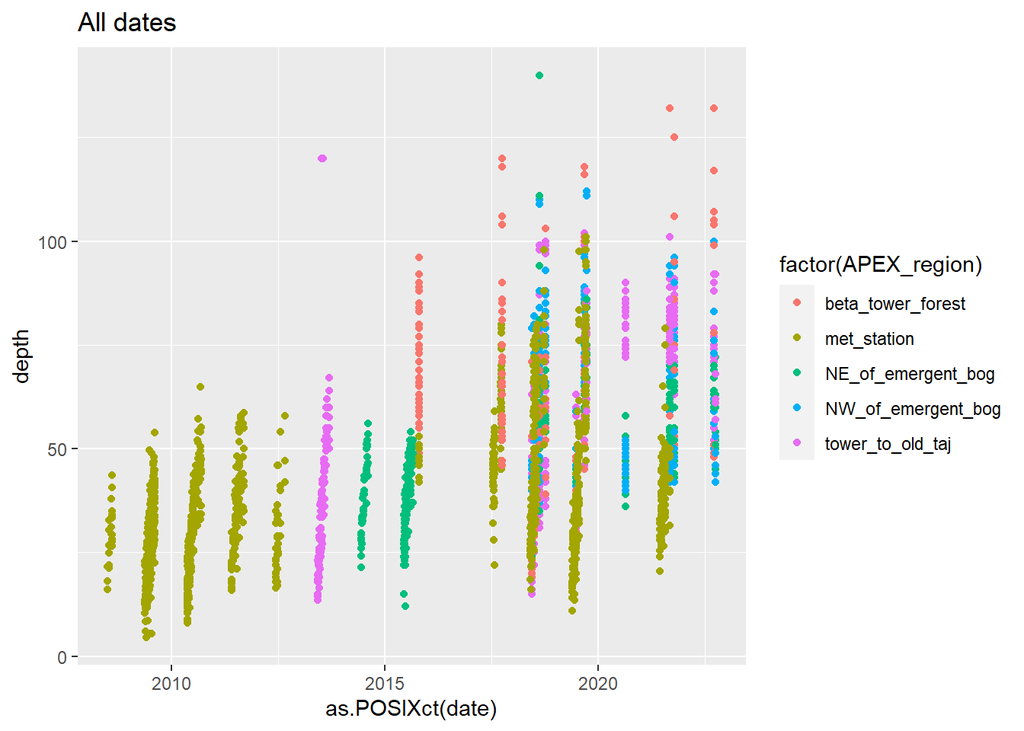

```r
all.region <- merge(all.gamma, region, by=c("site", "location"))
all.nonbog <- subset(all.region, APEX_region != "emergent_bog_area")
all.nonbog <- subset(all.nonbog, location!="439")
all.nonbog <- subset(all.nonbog, location!="440")
all.nonbog <- subset(all.nonbog, location!="441")
all.nonbog <- subset(all.nonbog, APEX_region != "towards_alpha")

all.plot <- ggplot() +
  geom_point(data=all.nonbog, aes(x=as.POSIXct(date), y=depth, color=factor(APEX_region))) +
  ggtitle("All dates")
print(all.plot)
```

## Active layer data

Only looking at data from August through October, so data not impacted by seasonal ice.

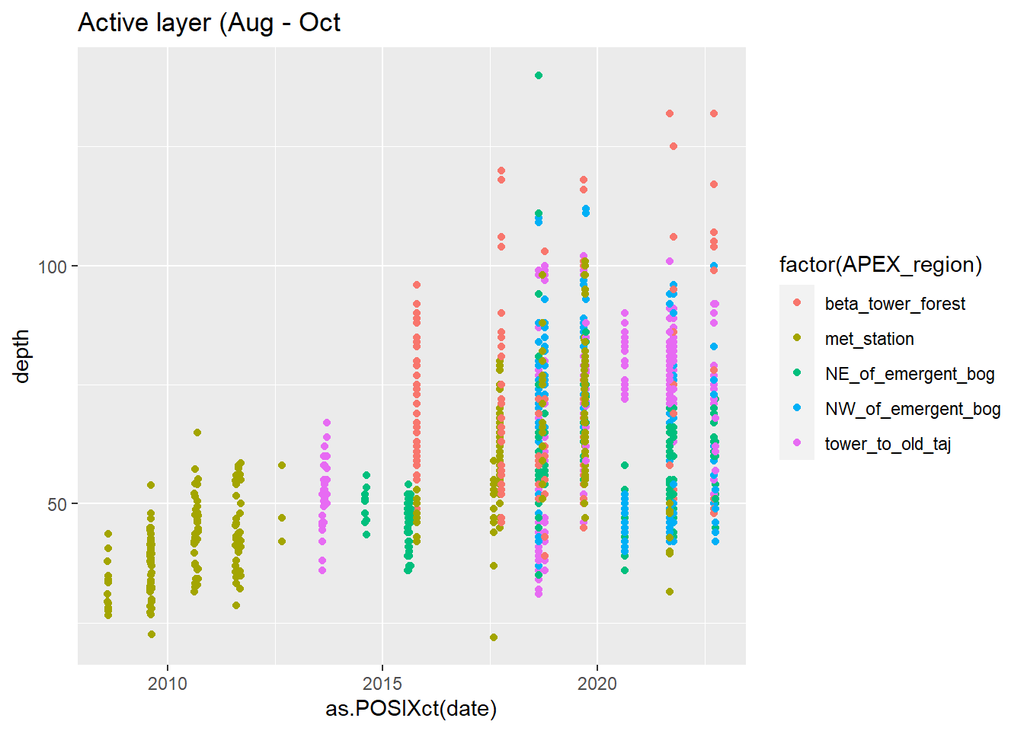

```r
august.on <- subset(all.nonbog, month(date)>=8)

aug.plot <- ggplot(data=august.on, aes(x=as.POSIXct(date), y=depth)) +
  geom_point(aes(color=factor(APEX_region))) +
  ggtitle("Active layer (Aug - Oct")
print(aug.plot)
```

## Statistics on the data

ADD POST-HOC TEST?

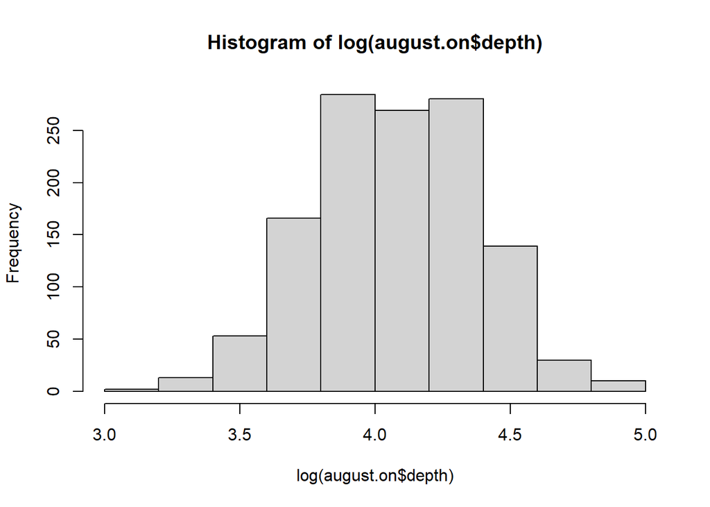

```r
august.on$year <- year(as.POSIXct(august.on$date, format="%Y-%m-%d", tz="America/Anchorage"))

#What's the distribution of the data?
#Log helps normality
hist(log(august.on$depth))
```

```r
AL.region.stats <- glm(data=august.on, log(depth) ~ factor(year) * APEX_region)
summary(AL.region.stats)
```

```
##
## Call:
## glm(formula = log(depth) ~ factor(year) * APEX_region, data = august.on)
##
## Deviance Residuals:
##      Min        1Q    Median        3Q       Max
## -0.95575  -0.13581   0.00986   0.12907   0.86736
##
## Coefficients: (36 not defined because of singularities)
##                                                Estimate Std. Error t value
## (Intercept)                                     4.12536    0.10400  39.666
## factor(year)2009                                0.12252    0.05898   2.077
## factor(year)2010                                0.27255    0.06073   4.488
## factor(year)2011                                0.25819    0.06148   4.200
## factor(year)2012                                0.38199    0.13165   2.902
## factor(year)2013                               -0.08101    0.13139  -0.617
## factor(year)2014                                0.09614    0.14334   0.671
## factor(year)2015                                0.08045    0.10770   0.747
## factor(year)2017                                0.11780    0.10879   1.083
## factor(year)2018                               -0.03629    0.11211  -0.324
## factor(year)2019                                0.10428    0.11720   0.890
## factor(year)2020                                0.38267    0.13478   2.839
## factor(year)2021                                0.24764    0.09483   2.612
## factor(year)2022                                0.27045    0.12027   2.249
## APEX_regionmet_station                         -0.62460    0.08989  -6.949
## APEX_regionNE_of_emergent_bog                  -0.33040    0.07798  -4.237
## APEX_regionNW_of_emergent_bog                  -0.31327    0.07890  -3.971
## APEX_regiontower_to_old_taj                    -0.11331    0.07183  -1.578
## factor(year)2009:APEX_regionmet_station              NA         NA      NA
## factor(year)2010:APEX_regionmet_station              NA         NA      NA
## factor(year)2011:APEX_regionmet_station              NA         NA      NA
## factor(year)2012:APEX_regionmet_station              NA         NA      NA
## factor(year)2013:APEX_regionmet_station              NA         NA      NA
## factor(year)2014:APEX_regionmet_station              NA         NA      NA
## factor(year)2015:APEX_regionmet_station         0.27006    0.11507   2.347
## factor(year)2017:APEX_regionmet_station         0.42823    0.09902   4.325
## factor(year)2018:APEX_regionmet_station         0.79452    0.11211   7.087
## factor(year)2019:APEX_regionmet_station         0.64778    0.10649   6.083
## factor(year)2020:APEX_regionmet_station              NA         NA      NA
## factor(year)2021:APEX_regionmet_station              NA         NA      NA
```

[output cut: 107 more lines]

```
## factor(year)2019:APEX_regiontower_to_old_taj    0.14866
## factor(year)2020:APEX_regiontower_to_old_taj         NA
## factor(year)2021:APEX_regiontower_to_old_taj    0.31246
## factor(year)2022:APEX_regiontower_to_old_taj         NA
## ---
## Signif. codes:  0 '***' 0.001 '**' 0.01 '*' 0.05 '.' 0.1 ' ' 1
##
## (Dispersion parameter for gaussian family taken to be 0.04378771)
##
##     Null deviance: 112.266  on 1245  degrees of freedom
## Residual deviance:  53.071  on 1212  degrees of freedom
##   (3 observations deleted due to missingness)
## AIC: -326.47
##
## Number of Fisher Scoring iterations: 2
```

```r
source("summarystats.R")
#For all regions and years
year.region.stats <- summarystats(august.on, measurevar="depth", groupvars=c("APEX_region", "year"), na.rm=TRUE)
print(year.region.stats)
```

```
##           APEX_region year   N    depth        sd        se        ci
## 1   beta_tower_forest 2015  56 68.19643 12.674125 1.6936512  3.394153
## 2   beta_tower_forest 2017  43 72.32558 21.211768 3.2347643  6.528019
## 3   beta_tower_forest 2018  25 60.72000 12.077941 2.4155883  4.985529
## 4   beta_tower_forest 2019  15 72.20000 24.678504 6.3719624 13.666500
## 5   beta_tower_forest 2021  24 85.87500 34.689069 7.0808766 14.647909
## 6   beta_tower_forest 2022  12 86.50000 30.164699 8.7077987 19.165736
## 7         met_station 2008  16 33.61250  5.941478 1.4853696  3.165990
## 8         met_station 2009  59 37.91186  5.729990 0.7459812  1.493244
## 9         met_station 2010  46 44.12609  7.389495 1.0895216  2.194409
## 10        met_station 2011  42 43.62381  8.047112 1.2416963  2.507656
## 11        met_station 2012   3 49.00000  8.185353 4.7258156 20.333544
## 12        met_station 2015  10 47.20000  3.910101 1.2364825  2.797118
## 13        met_station 2017  62 58.26613 10.431556 1.3248089  2.649119
## 14        met_station 2018  16 71.75000 12.423097 3.1057742  6.619801
```

[output cut: 20 more lines]

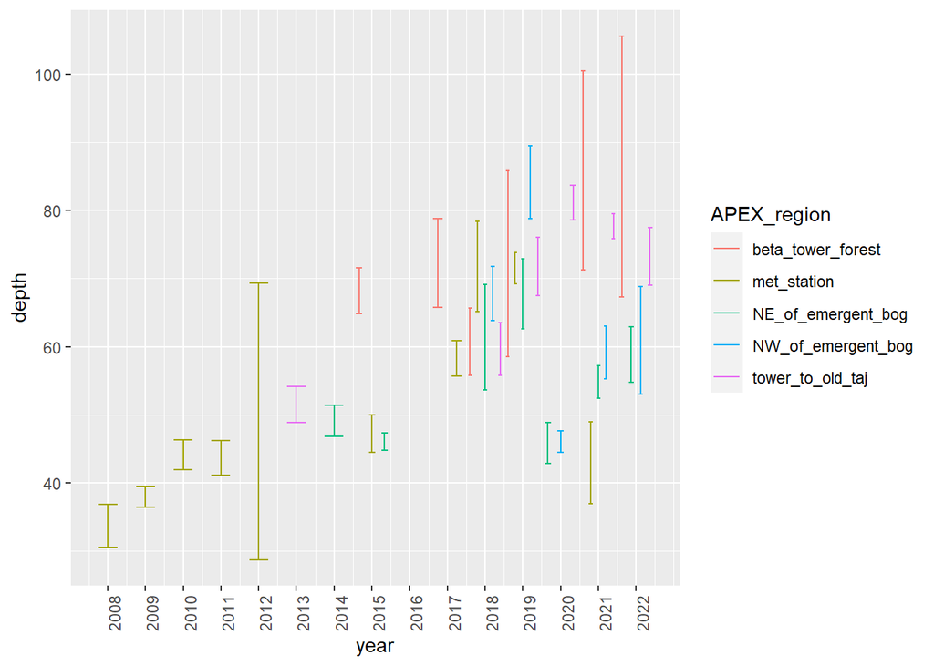

```r
write.csv(year.region.stats, "year.region.stats.csv")

plot.by.year <- ggplot(year.region.stats, aes(x=year, y=depth, color=APEX_region)) +
  geom_errorbar(aes(ymin=depth-ci, ymax=depth+ci), width=0.5, position=position_dodge(width=1)) +
  scale_x_continuous(breaks=seq(2008, 2022, 1)) +
  theme(axis.text.x = element_text(angle = 90))
print(plot.by.year)
```

## Plot all active lyear data with error

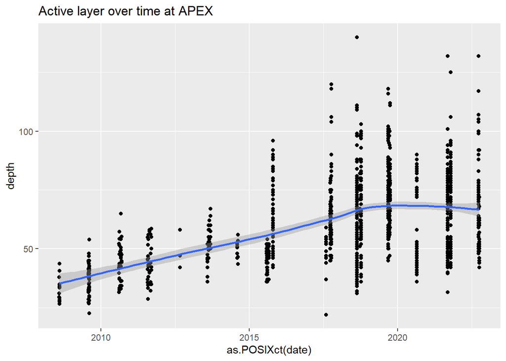

```r
error.plot <- ggplot(data=august.on) +
  geom_point(aes(x = as.POSIXct(date), y = depth)) +
  geom_smooth(aes(x = as.POSIXct(date), y = depth), method = "loess", formula = y ~ x) +
  ggtitle("Active layer over time at APEX")
print(error.plot)
```

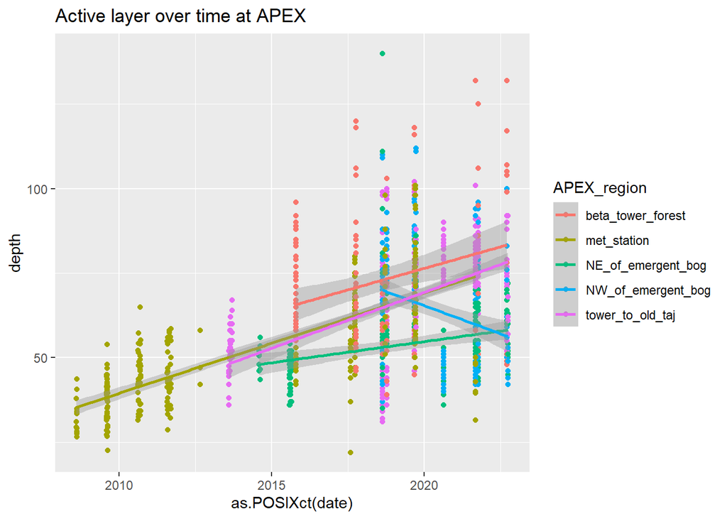

```r
region.error.plot <- ggplot(data=august.on) +
  geom_point(aes(x = as.POSIXct(date), y = depth, color=APEX_region)) +
  geom_smooth(aes(x = as.POSIXct(date), y = depth, color=APEX_region), method = "lm", formula = y ~ x) +
  ggtitle("Active layer over time at APEX")
print(region.error.plot)
```